# Data Communications: Data Transalation Challenge

Nick Huntington-Klein

Updated 2021-06-15

## Data Translation Challenge

This sheet will describe the data translation challenge assignment.

In this assignment, you will be given two datasets from the July monthly release from SafeGraph, which is a company that works with cell phone location data. If you’ve pressed “OK” to the agreements in certain apps, it sends anonymized information about where you are at a given time to location-data services, who then sell it to places like SafeGraph. You can see documentation for this data in the “Patterns” section of the [SafeGraph documentation](https://docs.safegraph.com/docs/weekly-patterns).

You will be taking this data, examining it, finding some interesting stories to tell, and telling them using visualizations and (a small amount of) text. I expect your document will contain at least five well-designed and well-executed visualizations, telling a coherent and interesting story.

Put some thought into these. Ask yourself “why am I making this visualization?” “Will the reader understand why I am making this visualization?” “What does this visualization add to the story?” and “Have I made this visualization as clear and visually appealing as I can make it?”

You will turn in an RMarkdown notebook containing your visualizations and a small amount of text linking them together or helping to tell the story. The result will be a report-style document that you might deliver in a business setting.

**Don’t just give me five random visualizations of the data**. I am looking for a *story* that should give me something *actionable* or *deeply interesting.* Ask yourself “who am I giving this report to, and what can they learn from it?” Each visualization should help add to the story. If, for example, you show that some industry is much busier on the weekends than weekdays, ask “why should I, or the reader, care that it’s busier on the weekends?” If you can answer that, great! Make sure it’s evident and as clear as possible on the graph or at least in the text why we should care. If you can’t answer that, do a different visualization.

Just because you’re using RMarkdown doesn’t mean your visualizations necessarily have to be in R. You can use Excel or (if you know it already) Tableau, export your visualizations as images, and include them as images using ! (outside of a code chunk) or `knitr::include_graphics()` (inside a code chunk). To get the data into Excel, open it up in R, do whatever cleaning or prepreparation you want on it (don’t forget to save your code in an .R file!) and then export it using the `write_excel_csv()` function in the **tidyverse**. You can then open that CSV file in Excel. In Tableau you can just open the .Rdata file directly (or open the file in R, do whatever preprocessing you like, then use `saveRDS()` to save it back as a different .Rdata file to open in Tableau).

You might find it worthwhile to peruse the [RMarkdown Cheat Sheet](https://www.rstudio.com/wp-content/uploads/2015/02/rmarkdown-cheatsheet.pdf) in any case. If you’ve gotten a little rusty on calculating and graphing summary statistics, see [this guide](https://lost-stats.github.io/Presentation/Figures/summary_graphs.html) for some example code to get you started. Also, **keep in mind that when you knit an RMarkdown file, it will by default set the working directory wherever the RMD file is saved. So you’ll probably want to keep your files in that same folder.** If you’re working with your code interactively, use Session $\rightarrow$ Set Working Directory to set your working directory to the folder with your files.

## The Data

I have already done some pre-processing on the data, and what results is two data sets that you can choose between.

**I VERY STRONGLY RECOMMEND READING ALL OF THIS DOCUMENTATION BEFORE YOU GET STARTED**. Reading data documentation is **an extremely important part** of data analytics, and routinely choosing not to do it will, without exaggeration, make you a bad data analyst whose work cannot be trusted. If some feature of the data is clearly spelled out here but your analysis or writeup misinterprets that feature of the data anyway, it will not be reflected kindly in your grade! If you have further questions about the data beyond what I’ve said here, please do ask me.

### king_dailyvisits.Rdata

`king_dailyvisits_load.Rdata` can be loaded in using the `load()` function. Put the file in your working directory (generally, the same folder you’ve saved your .RMD file in; you can then go Session $\rightarrow$ Set Working Directory to be sure), and load it in:

```r
load('king_dailyvisits_load.Rdata')
```

Let’s take a quick look:

```r
dv %>%
  arrange(brands, naics_title, date) %>%
  tail()
```

```
##             date naics_code           naics_title brands visits_by_day
## 37009 2020-07-26     451110 Sporting Goods Stores Zumiez            59
## 37010 2020-07-27     451110 Sporting Goods Stores Zumiez            53
## 37011 2020-07-28     451110 Sporting Goods Stores Zumiez            61
## 37012 2020-07-29     451110 Sporting Goods Stores Zumiez            56
## 37013 2020-07-30     451110 Sporting Goods Stores Zumiez            72
## 37014 2020-07-31     451110 Sporting Goods Stores Zumiez            69
```

This data set contains five variables:

- `date`, the date (in July 2020)
- `naics_code`, an industry coding system, which you can learn more about [here](https://www.naics.com/search/)
- `naics_title`, an explanatory title for the associated `naics_code`
- `brands`, a specific brand. Note that this is only present for large brands: McDonald’s, Macy’s, etc.. Smaller brands have no value here and are all lumped together with a blank value of `brands` (`brands == ''`).
- `visits_by_day`, the number of cell phones that SafeGraph recorded as visiting any location in brand `brand` and NAICS code `naics_code` on date `date` in King County.

So what we have here is information on foot traffic to various brands and industries in King County over a period of one month. This can be used to get a sense of the relative popularity of different brands or industries (or brands within industries), to see how popularity changes over time, to see how different traffic is on weekends versus weekdays - thinking up what to look at is up to you!

### king_originvisits.Rdata

`king_originvisits.Rdata` can be read in using the `load()` function. Put the file in your working directory (generally, the same folder you’ve saved your .RMD file in; you can then go Session $\rightarrow$ Set Working Directory to be sure), and load it in:

```r
load('king_originvisits_load.Rdata')
```

Let’s take a quick look. There are two types of variables in here. First, the SafeGraph data:

```r
ov %>%
  select(GEOID, naics_code, naics_title, brands, visits) %>%
  filter(brands != '') %>%
  head()
```

```
##          GEOID naics_code            naics_title             brands visits
## 1 530330073003     236118 Residential Remodelers California Closets      6
## 2 530330247013     236118 Residential Remodelers California Closets      8
## 3 530330233001     236118 Residential Remodelers California Closets      7
## 4 530330239003     236118 Residential Remodelers California Closets      4
## 5 530530723082     236118 Residential Remodelers California Closets      4
## 6 530610518033     236118 Residential Remodelers California Closets      4
```

The important variables we have here are:

- `GEOID`, the *census block group* identifier telling you the census block group that people **came from** to visit the store, **not where the store itself is**. This can be broken up into the state (53, Washington), the county (033, King County), the census tract (007300 in that first row), and the census block group (3 in the first row). These are common mapping distinctions created by the Census, generally used over zip codes because zip codes overlap counties and aren’t really intended for geographic use.
- `naics_code`, an industry coding system, which you can learn more about [here](https://www.naics.com/search/)
- `naics_title`, an explanatory title for the associated `naics_code`
- `brands`, a specific brand. Note that this is only present for large brands: McDonald’s, Macy’s, etc.. Smaller brands have no value here and are all lumped together (`brands == ''`)
- `visits`, the number of cell phone visits *on cell phones owned by people who appear to live in `GEOID`* that SafeGraph recorded as visiting any location in brand `brand` and NAICS code `naics_code` in the entire month of July (note that unlike `king_dailyvisits`, the whole month is lumped together). Also note that `GEOID` is the location where the *phone doing the visiting* appears to live (spends most of its nights there over the past six weeks), not the location *where the visit occurs*.
- An important feature of the data is that **visits are censored at 4.** That is, a value of 4 in the data could actually represent any value from 1 to 4. This is done to improve privacy. You can ignore this problem for making aggregate calculations like averages or sums (at least for this project you can; a professional would spend a lot more time with this issue), but avoid coming to conclusions that rely on the exact value like “look at all the census block groups that sent exactly 4 people to the McDonald’s on 3rd and Pine! Neat huh?” because that’s not actually true.

You can use this data to see how *different kinds of industries and/or brands are visited by people from different parts of the county*.

## Linking Origin Visits to Area

I want to be clear that **using the origin visits data is not a required part of this project**, and if you do use it there are many ways to do so, some of which don’t require you to link origin visits to areas you can name. You certainly aren’t required to make a map. But you may choose to do so!

There are two ways you can link the origin visits data to something you can name and thus use more easily.

The first is with the `neighborhood_names` file:

```r
load('neighborhood_names.Rdata')
ov %>%
  right_join(neighborhood_names) %>%
  tail()
```

```
##       naics_code                                              naics_title
## 30996     926120 Regulation and Administration of Transportation Programs
## 30997     926120 Regulation and Administration of Transportation Programs
## 30998     928120                                    International Affairs
## 30999     928120                                    International Affairs
## 31000     928120                                    International Affairs
## 31001     928120                                    International Affairs
##       brands        GEOID visits NEIGHBORHOOD_DISTRICT_NAME
## 30996        530330106002      4                  Southwest
## 30997        530330099003      4     Delridge Neighborhoods
## 30998        530330265001      4     Delridge Neighborhoods
## 30999        530330041002      4                  Northeast
## 31000        530330117004      4           Greater Duwamish
## 31001        530330066002      4                 Lake Union
```

This file will append Seattle neighborhood names to the census block groups. You could use this to, for example, get the average visits to some industry or brand by origin neighborhood. Keep in mind that these neighborhood names are **only for Seattle** and not the rest of the county.

Unfortunately, Excel doesn’t play nice with census block groups, and Tableau also has problems with it, so if you load this data in Excel it won’t work automatically (there are guides online for mapping census block groups in Excel - be my guest if you want to try. You might also have some luck with Tableau if you already know Tableau). So I recommend making the map with `ggplot` if you want to do a map. Thankfully, given the setup we already have, this is fairly easy. Just use `geom_sf()`.

You can bring in some map data in R easily using the **tigris** package. Making maps with **ggplot2** is a touch tricky in that it requires you to think about the exact format your map data comes from (once you have that down, the rest is standard **ggplot2**), but in the case of this data, 99% of you will be able to get by just fine either making no map at all, or copying and modifying the following code, which creates a heatmap by census block group based on some summary value:

[figure not shown]

```r
# Contains the geo_join and block_groups function
library(tigris)

# get King County block group map data
# progress_bar = FALSE keeps it from including a hundred lines of progress bar on your RMarkdown output
# cb = TRUE opts for less-detailed but much smaller map files
mapdata <- block_groups('WA','033', cb = TRUE, progress_bar = FALSE)

# THE PART FOR YOU TO CHANGE BASED ON YOUR ANALYSIS
# Your goal: summarize your data to the GEOID level, so that you have ONE NUMBER per GEOID that you want to graph
ov2 <- ov %>%
  # This particular example counts the number of visits to NAICS code 441120 or code 441320 in each area.
  # That's a single number (sum of visits to a set of codes) per area
  filter(naics_code %in% c(441120, 441320)) %>%
  # Now we want one observation per GEOID so group_by that
  group_by(GEOID) %>%
  # And summarize as we like so we get one observation per GEOID
  # We probably want to create the variable we'll be graphing on the map here
  summarise(visits = sum(visits))
#####

# Bring together our one-number-per-GEOID and the map data
map_and_data <- geo_join(mapdata, ov, by = 'GEOID', how = 'left')

# And graph as a heatmap
ggplot(map_and_data) +
  geom_sf(aes(fill = visits)) +
  theme_void() + # pretty much all maps want a void theme unless you really want to see latitude and longitude for some reason
  labs(fill = 'Total July Visits', title = 'Where People Visiting Car or Tile Dealers Live') # always label!
```

Note that the **tigris** data will also provide you with the variables `ALAND`, which is total land area in this `GEOID`, and `AWATER`, which is total water area in this `GEOID`. I don’t think I’ve seen anyone use these yet but you could!

Alternately, you may want to also bring in the `neighborhood_names` data to get a Seattle-specific by-neighborhood map. You could just `right_join` your `ov` and `neighborhood_names` to limit things just to Seattle and do the same heatmap as above, if you want a census block group heatmap but for Seattle only. Or you could do your calculations at the neighborhood level, by calculating the summary statistic to be the same in each neighborhood (use `group_by(NEIGHBORHOOD_DISTRICT_NAME) %>% mutate(calculation) %>% group_by(GEOID) %>% summarize(calculation = first(calculation)`). Or you could treat each neighborhood separately with `fill = NEIGHBORHOOD_DISTRICT_NAME`:

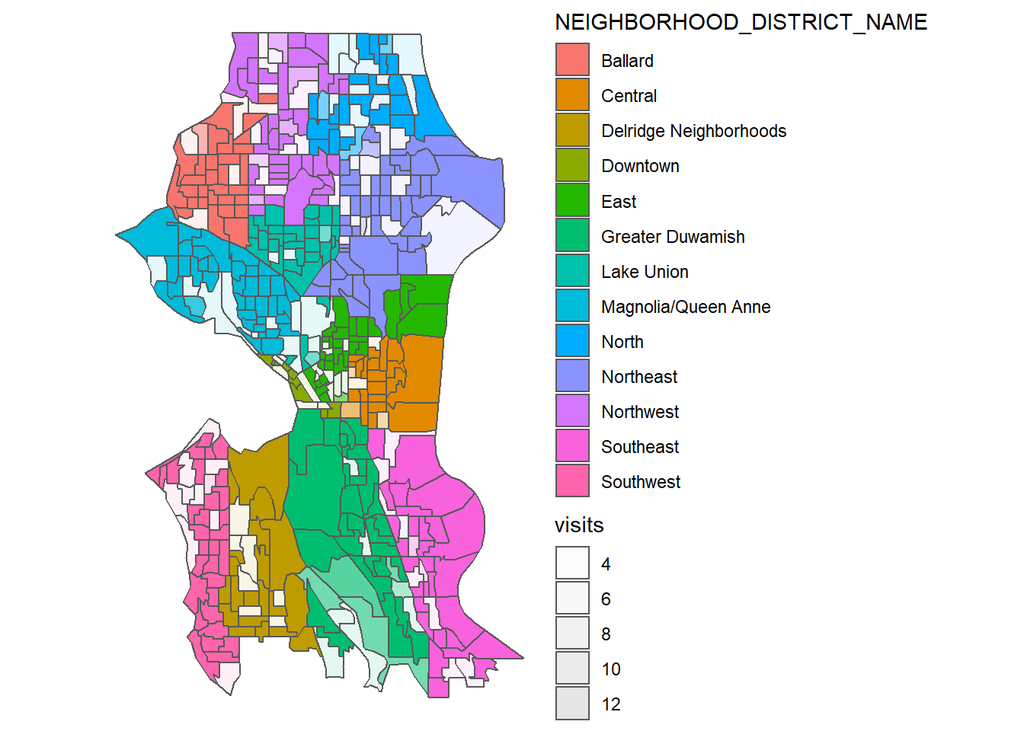

```r
ov3 <- ov2 %>%
  # the right join limits us automatically to GEOIDs that have neighborhood names
  right_join(neighborhood_names) %>%
  # DON'T group_by and summarize to neighborhood - we are just labeling the GEOIDs with neighborhood,
  # we don't have the map data to map each neighborhood as its own polygon
  # If we want to do something by-neighborhood, instead group_by neighborhood and use mutate instead of summarize
  group_by(NEIGHBORHOOD_DISTRICT_NAME) %>%
  mutate(neighb_visits = sum(visits, na.rm = TRUE))


# The "inner" join only takes the parts of the map that are in ov3 (i.e. have a neighborhood name)
map_w_neighborhoods <- geo_join(mapdata, ov3, by = 'GEOID', how = 'inner')

# And graph as a heatmap
# I'm not sure I like this alpha-shading for the visits, but this is just one way you could do it
ggplot(map_w_neighborhoods) +
  geom_sf(aes(fill = NEIGHBORHOOD_DISTRICT_NAME,
              alpha = visits)) +
  theme_void()
```

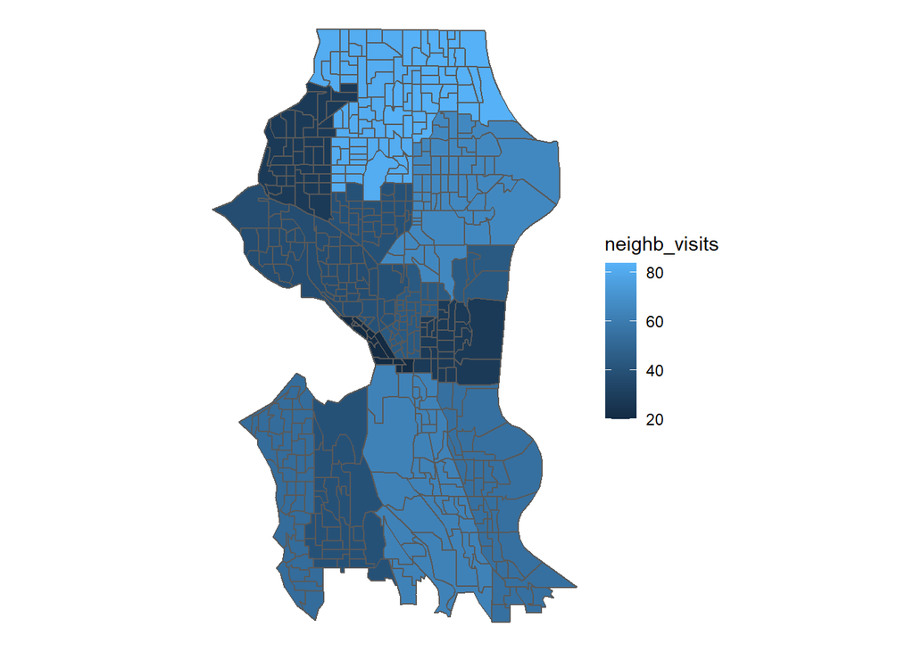

```r
# Use the variant that's the same for each neighborhood
ggplot(map_w_neighborhoods) +
  geom_sf(aes(fill = neighb_visits)) +
  theme_void()
```

Be wary of relying on a legend for too many categories, like the neighborhood-coloring map does here (these graphs are also woefully incomplete for other reasons - they are badly labeled!). Unusable legend! One alternative to this is the use of the **ggsflabel** package, which is not on CRAN and must be installed via GitHub with `remotes::install_github('yutannihilation/ggsflabel')`:

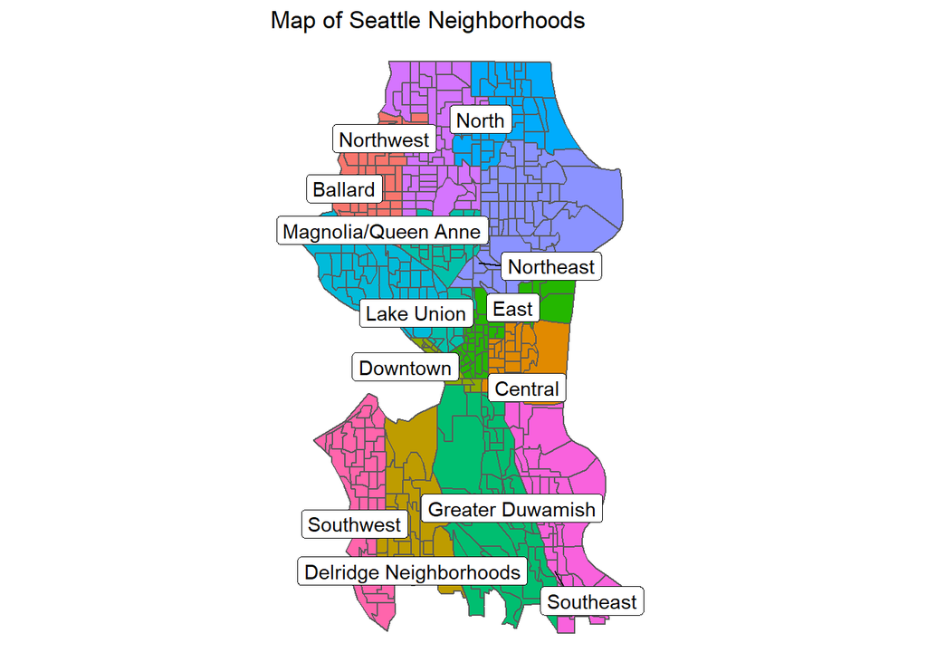

```r
# ggrepel doesn't work with geom_sf,
# and geom_sf_label makes an overlapping mess,
# but there's a special geom_sf_label_repel in this package:
# remotes::install_github('yutannihilation/ggsflabel')
library(ggsflabel)

neighbmap <- ov %>%
  # Only draw Seattle
  right_join(neighborhood_names) %>%
  # Only label each neighborhood once
  group_by(NEIGHBORHOOD_DISTRICT_NAME) %>%
  mutate(neighborhood_label =
           case_when(
             row_number() == 1 ~ NEIGHBORHOOD_DISTRICT_NAME,
             TRUE ~ NA_character_
           )) %>%
  ungroup()

# 'inner' here only picks rows that successfully match, i.e. Seattle-only since we
# already limited neighbmap to Seattpe
neighbmap <- geo_join(mapdata, neighbmap, by = 'GEOID', how = 'inner')

neighbmap %>%
  # THE IMPORTANT PART:
  ggplot() +
  geom_sf(aes(fill = NEIGHBORHOOD_DISTRICT_NAME)) +
  theme_void() +
  guides(fill = FALSE) +
  labs(title = 'Map of Seattle Neighborhoods') +
  geom_sf_label_repel(aes(label = neighborhood_label))
```

## Grading

- 5%: Completing all tasks (five visualizations in an RMarkdown doc, with a story and text connecting them)
- 15%: Coherent and well-explained story
- 60%: Solid visual design following the principles we’ve discussed, graphs that actually relate to the story and reveal information about it
- 20%: Clear and concise writing

## Notes on Working with Data

- You can use one data set for all your visualizations, or both. No bonus points for picking one over the other, or for doing both, just use whatever is effective. You’re also not required to do a map.
- If you *are* going to do a map, you almost certainly want to produce a data set with *one row per GEOID* before merging with the map data. This can be accomplished with a `group_by(GEOID) %>% summarize()` of some sort. You want to do this *before* `geo_join`, and in general don’t want to be messing with the data much after `geo_join` as some of the **dplyr** commands won’t work for geographic data.
- The industry codes are at the very fine six-digit level. However, they are designed such that the first two digits are broad categories, the first four digits are more specific categories, and the full six digits are the most specific. If you want to look at a broader category (say, “retail”), you can look up the two- (or four-) digit broad categories [here](https://www.naics.com/search/). Then, you can turn the six-digit categories into two-digit categories using `dv <- dv %>% mutate(naics_two_digit = floor(naics_code/10000))` or to four-digit using `dv <- dv %>% mutate(naics_four_digit = floor(naics_code/100))`
- A given `naics_code` is in there multiple times per day - once for each `brand` there is in the data for it, plus one for locations without brand information in the data (`brand == ''`). If you don’t care about the different brands and just want to use a full `naics_code`, you should collapse to the `naics_code` level using `dv_naics <- dv %>% group_by(naics_code, naics_title, date) %>% summarize(visits_by_day = sum(visits_by_day))` (drop the `naics_title` part if you’re using `naics_two_digit` or `naics_four_digit` instead of `naics_code`). Or use a pivot table if you’re in Excel.
- You can bring in additional data or information if you want (there’s some interesting census demographic/income data out there grouped by census block group) but this is not necessary and will likely be a lot of work.
- Please label your graphs.
- Some of the `naics_title` values are ambiguous, confusing, or too long. Consider replacing long labels with your own (see code example below). Be sure to use the [NAICS website](https://www.naics.com/search/) to understand the categories you do use. A big one that’s still confusing even with the website is “Lessors of Nonresidential Real Estate” - you can think of this as “malls” although that’s a bit of a simplification.

Example code for relabeling `naics_title`:

```r
dv <- dv %>%
  mutate(naics_title = case_when(
    naics_title == 'old label 1' ~ 'new label 1',
    naics_title == 'old label 2' ~ 'new label 2',
    TRUE ~ naics_title # don't change the rest
  ))
```